# FRED-MD: outliers, missing values, stationarity

Alessandro Ciancetta

2023-04-16

# Data preparation

```r
## Load code from script folders
preprocessing_scripts_env <- new.env()
file.sources = list.files(paste0(getwd(), c("/sourcecode/data_preprocessing/")),
                          pattern=".R$", full.names=TRUE,
                          ignore.case=TRUE)
sapply(file.sources, source, preprocessing_scripts_env)
attach(preprocessing_scripts_env, name="sourced_scripts")
```

In this notebook, we will prepare the FRED-MD data for the analysis. We will follow McCracken and Ng (2016) for handling missing values and outliers. We will also follow their rules for transforming the series and make them stationary.

Notice that the notebook shows the whole procedure on the current vintage of the dataset for illustrative purposes. The steps for preparing the dataset are then collected in a function that will be used in the actual real-time forecast evaluation using all the vintages of FRED-MD.

## Loading the data and first inspection

```r
fredmd <- read.csv("data/current.csv")

## The first row contains the transformation codes
d <- as_tibble(fredmd[-1,])
tcodes <- unlist(fredmd[1,-1])
```

```r
## Codes for transformations in Mc Cracken and Ng 2015
fredmd[1,][1:10]
```

```
##      sasdate RPI W875RX1 DPCERA3M086SBEA CMRMTSPLx RETAILx INDPRO IPFPNSS
## 1 Transform:   5       5               5         5       5      5       5
##   IPFINAL IPCONGD
## 1       5       5
```

```r
## Variables
var_names <- names(d)[-1]
print(length(var_names))
```

```
## [1] 127
```

```r
print(var_names)
```

```
##   [1] "RPI"             "W875RX1"         "DPCERA3M086SBEA" "CMRMTSPLx"
##   [5] "RETAILx"         "INDPRO"          "IPFPNSS"         "IPFINAL"
##   [9] "IPCONGD"         "IPDCONGD"        "IPNCONGD"        "IPBUSEQ"
##  [13] "IPMAT"           "IPDMAT"          "IPNMAT"          "IPMANSICS"
##  [17] "IPB51222S"       "IPFUELS"         "CUMFNS"          "HWI"
##  [21] "HWIURATIO"       "CLF16OV"         "CE16OV"          "UNRATE"
##  [25] "UEMPMEAN"        "UEMPLT5"         "UEMP5TO14"       "UEMP15OV"
##  [29] "UEMP15T26"       "UEMP27OV"        "CLAIMSx"         "PAYEMS"
##  [33] "USGOOD"          "CES1021000001"   "USCONS"          "MANEMP"
##  [37] "DMANEMP"         "NDMANEMP"        "SRVPRD"          "USTPU"
##  [41] "USWTRADE"        "USTRADE"         "USFIRE"          "USGOVT"
##  [45] "CES0600000007"   "AWOTMAN"         "AWHMAN"          "HOUST"
##  [49] "HOUSTNE"         "HOUSTMW"         "HOUSTS"          "HOUSTW"
##  [53] "PERMIT"          "PERMITNE"        "PERMITMW"        "PERMITS"
##  [57] "PERMITW"         "ACOGNO"          "AMDMNOx"         "ANDENOx"
```

[output cut: 17 more lines]

```r
cat("\nThe last observation is missing for", sum(is.na(d[nrow(d),])), "variables")
```

```
##
## The last observation is missing for 127 variables
```

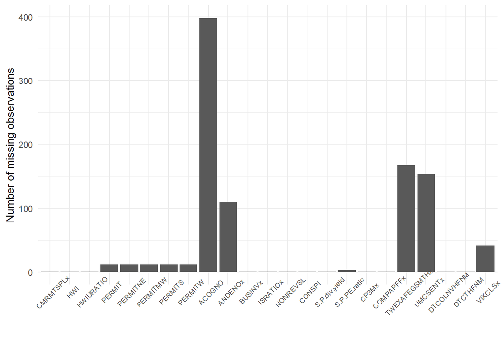

```r
count_missing(d[-nrow(d),])
```

### Policy-relevant variables

Following Kim and Swanson (2010) we consider the 10 key variables reported in the table below. The table also reports 6 policy-relevant variables mentioned in that paper.

| Variable | Description |
| --- | --- |
| UNRATE | Unemployment rate |
| W875RX1 | Real personal income ex transfer receipts |
| GS10 | 10-Year Treasury Rate |
| CPIAUCSL | Consumer price index (all items) |
| WPSFD49207 | Producer Price Index (Finished goods) |
| PAYEMS | All Employees (total monfarm) |
| HOUST | Housing Starts (Total New Privately Owned) |
| INDPRO | Industrial production |
| M2SL | M2 Money Stock |
| S.P.500 | S&P500 Common Stock Price Index: Composite |
| —– | —– |
| RETAILx | Retail and Food Services Sales |
| ISRATIOx | Total Business: Inventories to Sales Ratio |
| AMDMNOx | New Orders for Durable Goods |
| AMDMUOx | Unfilled Orders for Durable Goods |
| NAPMNOI | ISM : New Orders Index (aka purchasing managers’ index (PMI)) |
| NAPMII | ISM : Inventories Index |
| —– | —– |
| GNP not available at monthly frequency |  |

*Remark*: the series PPIFGS (Producer price index of finished goods) has been discontinued from the 2016-03 vintage. The new varaible for the PPI index of finished goods is WPSFD49207.

```r
target_variables <- c("UNRATE", "W875RX1", "GS10",
                      "CPIAUCSL", "WPSFD49207", "PAYEMS",
                      "HOUST", "INDPRO", "M2SL", "S.P.500")

extra_variables <- c("RETAILx", "ISRATIOx", "AMDMNOx",
                     "AMDMUOx", "NAPMNOI", "NAPMII")
```

## Transformation

The column `tcode` denotes the following data transformation for a series $x$: (1) no transformation; (2) $\Delta x_t$; (3) $\Delta^2 x_T$; (4) $\log(x_t)$; (5) $\Delta\log(x_t)$; (6) $\Delta^2\log(x_t)$ (7) $\Delta(x_t / x_{t-1} -1)$.

```r
d_stationary <- transform_fred(d, tcode = tcodes)
```

```
## Column 2, RPI. Transformation 5 (logDiff)
```

```
## Column 3, W875RX1. Transformation 5 (logDiff)
```

```
## Column 4, DPCERA3M086SBEA. Transformation 5 (logDiff)
```

```
## Column 5, CMRMTSPLx. Transformation 5 (logDiff)
```

```
## Column 6, RETAILx. Transformation 5 (logDiff)
```

```
## Column 7, INDPRO. Transformation 5 (logDiff)
```

```
## Column 8, IPFPNSS. Transformation 5 (logDiff)
```

```
## Column 9, IPFINAL. Transformation 5 (logDiff)
```

```
## Column 10, IPCONGD. Transformation 5 (logDiff)
```

```
## Column 11, IPDCONGD. Transformation 5 (logDiff)
```

```
## Column 12, IPNCONGD. Transformation 5 (logDiff)
```

```
## Column 13, IPBUSEQ. Transformation 5 (logDiff)
```

```
## Column 14, IPMAT. Transformation 5 (logDiff)
```

```
## Column 15, IPDMAT. Transformation 5 (logDiff)
```

```
## Column 16, IPNMAT. Transformation 5 (logDiff)
```

```
## Column 17, IPMANSICS. Transformation 5 (logDiff)
```

```
## Column 18, IPB51222S. Transformation 5 (logDiff)
```

```
## Column 19, IPFUELS. Transformation 5 (logDiff)
```

```
## Column 20, CUMFNS. Transformation 2 (Diff)
```

```
## Column 21, HWI. Transformation 2 (Diff)
```

```
## Column 22, HWIURATIO. Transformation 2 (Diff)
```

```
## Column 23, CLF16OV. Transformation 5 (logDiff)
```

```
## Column 24, CE16OV. Transformation 5 (logDiff)
```

```
## Column 25, UNRATE. Transformation 2 (Diff)
```

```
## Column 26, UEMPMEAN. Transformation 2 (Diff)
```

```
## Column 27, UEMPLT5. Transformation 5 (logDiff)
```

```
## Column 28, UEMP5TO14. Transformation 5 (logDiff)
```

```
## Column 29, UEMP15OV. Transformation 5 (logDiff)
```

```
## Column 30, UEMP15T26. Transformation 5 (logDiff)
```

```
## Column 31, UEMP27OV. Transformation 5 (logDiff)
```

```
## Column 32, CLAIMSx. Transformation 5 (logDiff)
```

```
## Column 33, PAYEMS. Transformation 5 (logDiff)
```

```
## Column 34, USGOOD. Transformation 5 (logDiff)
```

```
## Column 35, CES1021000001. Transformation 5 (logDiff)
```

```
## Column 36, USCONS. Transformation 5 (logDiff)
```

```
## Column 37, MANEMP. Transformation 5 (logDiff)
```

```
## Column 38, DMANEMP. Transformation 5 (logDiff)
```

```
## Column 39, NDMANEMP. Transformation 5 (logDiff)
```

```
## Column 40, SRVPRD. Transformation 5 (logDiff)
```

```
## Column 41, USTPU. Transformation 5 (logDiff)
```

```
## Column 42, USWTRADE. Transformation 5 (logDiff)
```

```
## Column 43, USTRADE. Transformation 5 (logDiff)
```

```
## Column 44, USFIRE. Transformation 5 (logDiff)
```

```
## Column 45, USGOVT. Transformation 5 (logDiff)
```

```
## Column 46, CES0600000007. Transformation 1 (Identity)
```

```
## Column 47, AWOTMAN. Transformation 2 (Diff)
```

```
## Column 48, AWHMAN. Transformation 1 (Identity)
```

```
## Column 49, HOUST. Transformation 4 (log)
```

```
## Column 50, HOUSTNE. Transformation 4 (log)
```

```
## Column 51, HOUSTMW. Transformation 4 (log)
```

```
## Column 52, HOUSTS. Transformation 4 (log)
```

```
## Column 53, HOUSTW. Transformation 4 (log)
```

```
## Column 54, PERMIT. Transformation 4 (log)
```

```
## Column 55, PERMITNE. Transformation 4 (log)
```

```
## Column 56, PERMITMW. Transformation 4 (log)
```

```
## Column 57, PERMITS. Transformation 4 (log)
```

```
## Column 58, PERMITW. Transformation 4 (log)
```

```
## Column 59, ACOGNO. Transformation 5 (logDiff)
```

```
## Column 60, AMDMNOx. Transformation 5 (logDiff)
```

```
## Column 61, ANDENOx. Transformation 5 (logDiff)
```

```
## Column 62, AMDMUOx. Transformation 5 (logDiff)
```

```
## Column 63, BUSINVx. Transformation 5 (logDiff)
```

```
## Column 64, ISRATIOx. Transformation 2 (Diff)
```

```
## Column 65, M1SL. Transformation 6 (logDiff2)
```

```
## Column 66, M2SL. Transformation 6 (logDiff2)
```

```
## Column 67, M2REAL. Transformation 5 (logDiff)
```

```
## Column 68, BOGMBASE. Transformation 6 (logDiff2)
```

```
## Column 69, TOTRESNS. Transformation 6 (logDiff2)
```

```
## Column 70, NONBORRES. Transformation 7 (diffp)
```

```
## Column 71, BUSLOANS. Transformation 6 (logDiff2)
```

```
## Column 72, REALLN. Transformation 6 (logDiff2)
```

```
## Column 73, NONREVSL. Transformation 6 (logDiff2)
```

```
## Column 74, CONSPI. Transformation 2 (Diff)
```

```
## Column 75, S.P.500. Transformation 5 (logDiff)
```

```
## Column 76, S.P..indust. Transformation 5 (logDiff)
```

```
## Column 77, S.P.div.yield. Transformation 2 (Diff)
```

```
## Column 78, S.P.PE.ratio. Transformation 5 (logDiff)
```

```
## Column 79, FEDFUNDS. Transformation 2 (Diff)
```

```
## Column 80, CP3Mx. Transformation 2 (Diff)
```

```
## Column 81, TB3MS. Transformation 2 (Diff)
```

```
## Column 82, TB6MS. Transformation 2 (Diff)
```

```
## Column 83, GS1. Transformation 2 (Diff)
```

```
## Column 84, GS5. Transformation 2 (Diff)
```

```
## Column 85, GS10. Transformation 2 (Diff)
```

```
## Column 86, AAA. Transformation 2 (Diff)
```

```
## Column 87, BAA. Transformation 2 (Diff)
```

```
## Column 88, COMPAPFFx. Transformation 1 (Identity)
```

```
## Column 89, TB3SMFFM. Transformation 1 (Identity)
```

```
## Column 90, TB6SMFFM. Transformation 1 (Identity)
```

```
## Column 91, T1YFFM. Transformation 1 (Identity)
```

```
## Column 92, T5YFFM. Transformation 1 (Identity)
```

```
## Column 93, T10YFFM. Transformation 1 (Identity)
```

```
## Column 94, AAAFFM. Transformation 1 (Identity)
```

```
## Column 95, BAAFFM. Transformation 1 (Identity)
```

```
## Column 96, TWEXAFEGSMTHx. Transformation 5 (logDiff)
```

```
## Column 97, EXSZUSx. Transformation 5 (logDiff)
```

```
## Column 98, EXJPUSx. Transformation 5 (logDiff)
```

```
## Column 99, EXUSUKx. Transformation 5 (logDiff)
```

```
## Column 100, EXCAUSx. Transformation 5 (logDiff)
```

```
## Column 101, WPSFD49207. Transformation 6 (logDiff2)
```

```
## Column 102, WPSFD49502. Transformation 6 (logDiff2)
```

```
## Column 103, WPSID61. Transformation 6 (logDiff2)
```

```
## Column 104, WPSID62. Transformation 6 (logDiff2)
```

```
## Column 105, OILPRICEx. Transformation 6 (logDiff2)
```

```
## Column 106, PPICMM. Transformation 6 (logDiff2)
```

```
## Column 107, CPIAUCSL. Transformation 6 (logDiff2)
```

```
## Column 108, CPIAPPSL. Transformation 6 (logDiff2)
```

```
## Column 109, CPITRNSL. Transformation 6 (logDiff2)
```

```
## Column 110, CPIMEDSL. Transformation 6 (logDiff2)
```

```
## Column 111, CUSR0000SAC. Transformation 6 (logDiff2)
```

```
## Column 112, CUSR0000SAD. Transformation 6 (logDiff2)
```

```
## Column 113, CUSR0000SAS. Transformation 6 (logDiff2)
```

```
## Column 114, CPIULFSL. Transformation 6 (logDiff2)
```

```
## Column 115, CUSR0000SA0L2. Transformation 6 (logDiff2)
```

```
## Column 116, CUSR0000SA0L5. Transformation 6 (logDiff2)
```

```
## Column 117, PCEPI. Transformation 6 (logDiff2)
```

```
## Column 118, DDURRG3M086SBEA. Transformation 6 (logDiff2)
```

```
## Column 119, DNDGRG3M086SBEA. Transformation 6 (logDiff2)
```

```
## Column 120, DSERRG3M086SBEA. Transformation 6 (logDiff2)
```

```
## Column 121, CES0600000008. Transformation 6 (logDiff2)
```

```
## Column 122, CES2000000008. Transformation 6 (logDiff2)
```

```
## Column 123, CES3000000008. Transformation 6 (logDiff2)
```

```
## Column 124, UMCSENTx. Transformation 2 (Diff)
```

```
## Column 125, DTCOLNVHFNM. Transformation 6 (logDiff2)
```

```
## Column 126, DTCTHFNM. Transformation 6 (logDiff2)
```

```
## Column 127, INVEST. Transformation 6 (logDiff2)
```

```
## Column 128, VIXCLSx. Transformation 1 (Identity)
```

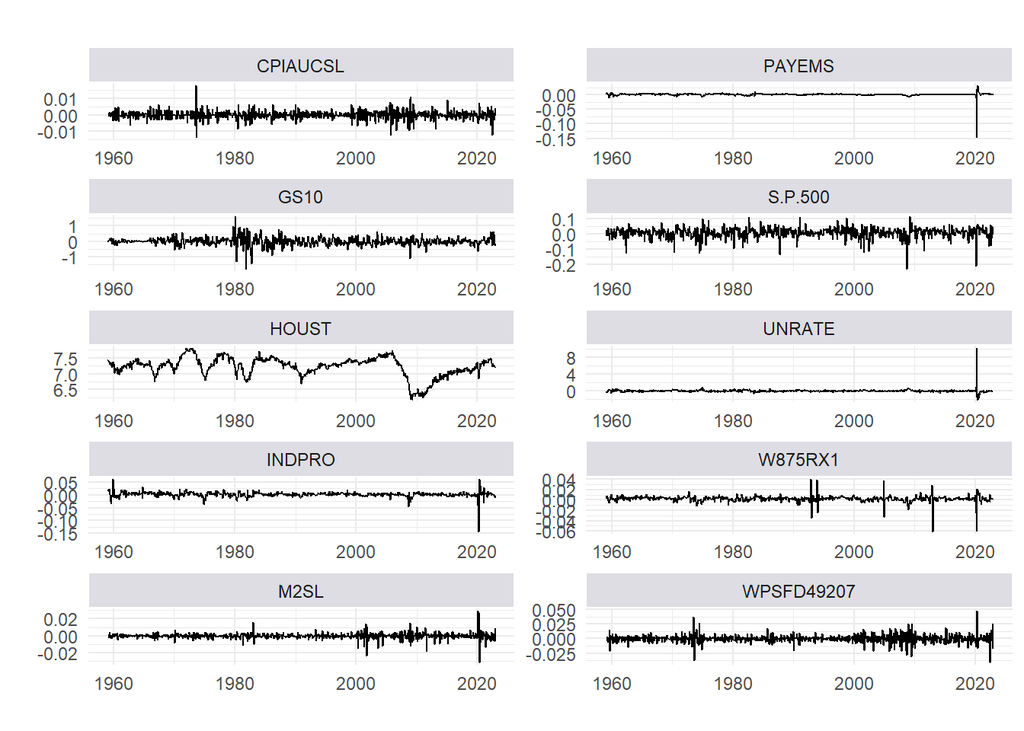

```r
plot_ts(d_stationary[,target_variables], date = d_stationary[,1], n_row = 5)
```

```r
cat("\n", sum(is.na(d_stationary)) - sum(is.na(d)), "missing values have been introduced")
```

```
##
##  215 missing values have been introduced
```

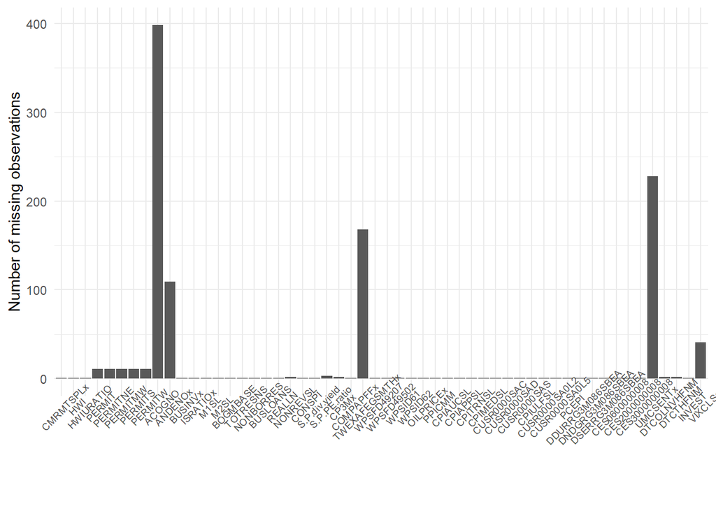

```r
count_missing(d_stationary[-c(1, nrow(d_stationary)),])
```

## Imputation

### Outliers detection

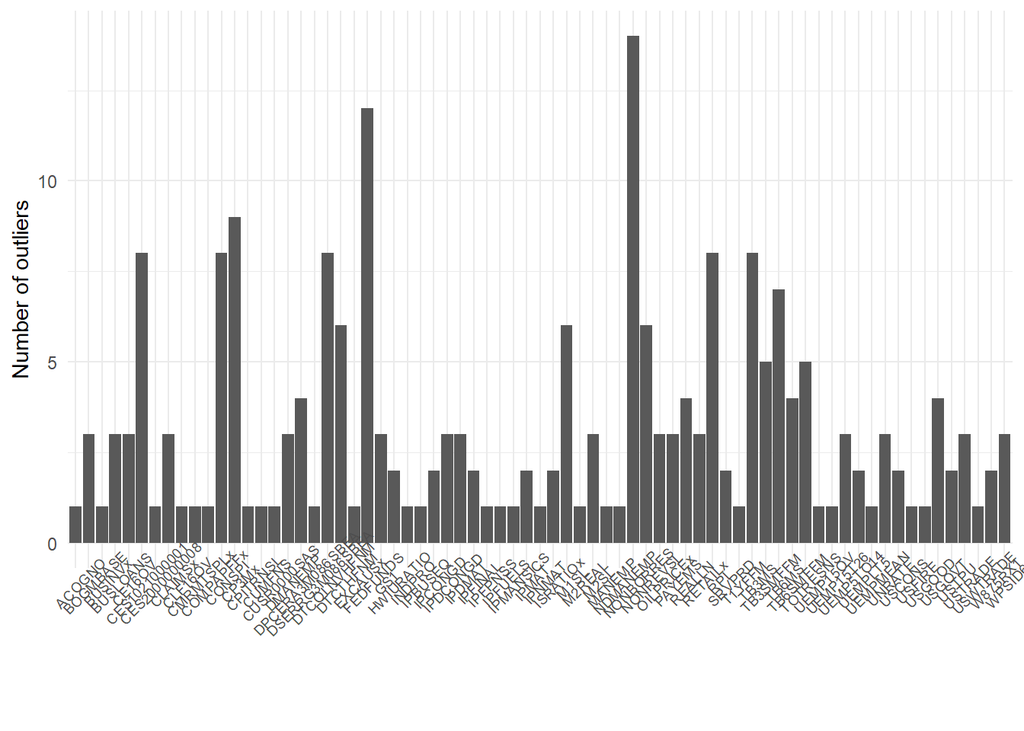

```r
count_outlier(d_stationary)
```

```r
## Outliers to NAs
d_outlier <- outlier_to_missing(d_stationary)
```

```r
cat("\n", sum(is.na(d_outlier)) - sum(is.na(d_stationary)), "missing values have been introduced")
```

```
##
##  151 missing values have been introduced
```

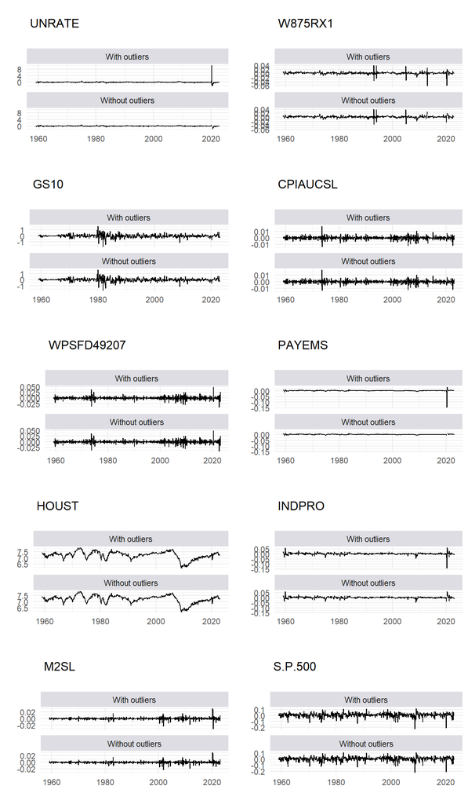

```r
compare_data(d_stationary, d_outlier,
             variable_list = target_variables,
             ribbon_labs = c("With outliers", "Without outliers")
             )
```

### Imputation of the missing values

```r
d_imputed <- em_impute(d_outlier, r = 8)
```

```
## Distance is: 1.6718 Distance is: 3.3624 Distance is: 0.0903 Distance is: 0.0649
## Distance is: 0.0523 Distance is: 3.1116 Distance is: 0.0406 Distance is: 3.2676
## Distance is: 0.0349 Distance is: 0.0323 Distance is: 0.0298 Distance is: 0.0273
## Distance is: 0.0249 Distance is: 0.0227 Distance is: 1.0722 Distance is: 0.019
## Distance is: 0.0174 Distance is: 0.016 Distance is: 0.0148 Distance is: 0.0137
## Distance is: 0.0127 Distance is: 0.0118 Distance is: 0.011 Distance is: 0.0103
## Distance is: 0.0096
```

```r
# d_imputed <- extract_and_fill(d_outlier, r = 8)$imputed ## Previous code, gives even more smoothed imputated values
```

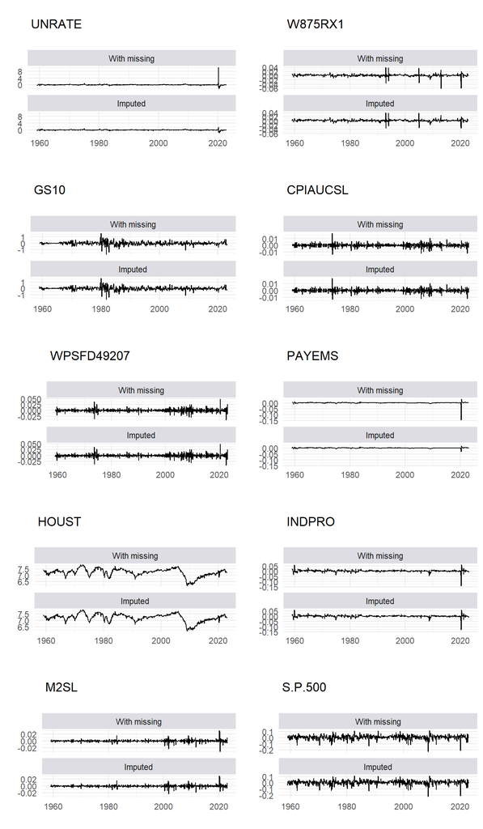

```r
compare_data(d_stationary, d_imputed,
             variable_list = target_variables,
             ribbon_labs = c("With missing", "Imputed")
             )
```

## Pipeline function

The following function wraps up the code and will be used during the forecast evaluation.

```r
preprocess_fredmd <- function(fredmd, r = 8, thresh = 0.01, verbose = TRUE){
  ## extract data and transformation codes
  d <- as_tibble(fredmd[-1,])
  tcodes <- unlist(fredmd[1,-1])

  ## execute the preprocessing pipeline
  d_stationary <- transform_fred(d, tcode = tcodes)
  d_outlier <- outlier_to_missing(d_stationary)
  # d_imputed <- extract_and_fill(d_outlier, r = 8)$imputed
  d_imputed <- em_impute(d_outlier, r, thresh, verbose)

  ## output
  return(d_imputed)
}
```

```r
preprocessed_data <- preprocess_fredmd(fredmd)
```

```r
preprocessed_data
```

```
## # A tibble: 770 x 128
##    sasdate         RPI   W875RX1 DPCERA3M0~1 CMRMTS~2  RETAILx   INDPRO  IPFPNSS
##    <chr>         <dbl>     <dbl>       <dbl>    <dbl>    <dbl>    <dbl>    <dbl>
##  1 1/1/1959   0.00191   0.00178      0.00408  5.17e-3  5.88e-3  0.00880  0.00810
##  2 2/1/1959   0.00393   0.00361      0.0104   7.36e-3  7.31e-3  0.0194   0.0134
##  3 3/1/1959   0.00643   0.00736      0.00941 -3.42e-3  8.32e-3  0.0143   0.00603
##  4 4/1/1959   0.00649   0.00705     -0.00364  1.99e-2  6.16e-4  0.0211   0.0143
##  5 5/1/1959   0.00576   0.00662      0.0120   6.80e-3  7.80e-3  0.0150   0.00827
##  6 6/1/1959   0.00310   0.00297      0.00371 -5.15e-5  9.06e-3  0.00114  0.00704
##  7 7/1/1959  -0.000589 -0.000764    -0.00343  1.21e-2 -3.30e-4 -0.0242   0.00117
##  8 8/1/1959  -0.00564  -0.00575      0.00600 -5.24e-2  6.36e-3 -0.0345  -0.00703
##  9 9/1/1959   0.000721  0            0.0100   1.46e-2 -1.32e-2 -0.00121 -0.00471
## 10 10/1/1959  0.00128   0.00115     -0.00684  1.60e-3  7.29e-3 -0.00729 -0.00236
## # ... with 760 more rows, 120 more variables: IPFINAL <dbl>, IPCONGD <dbl>,
## #   IPDCONGD <dbl>, IPNCONGD <dbl>, IPBUSEQ <dbl>, IPMAT <dbl>, IPDMAT <dbl>,
## #   IPNMAT <dbl>, IPMANSICS <dbl>, IPB51222S <dbl>, IPFUELS <dbl>,
## #   CUMFNS <dbl>, HWI <dbl>, HWIURATIO <dbl>, CLF16OV <dbl>, CE16OV <dbl>,
## #   UNRATE <dbl>, UEMPMEAN <dbl>, UEMPLT5 <dbl>, UEMP5TO14 <dbl>,
## #   UEMP15OV <dbl>, UEMP15T26 <dbl>, UEMP27OV <dbl>, CLAIMSx <dbl>,
## #   PAYEMS <dbl>, USGOOD <dbl>, CES1021000001 <dbl>, USCONS <dbl>, ...
```

```r
# check that wrapper function gives the same result
sum(preprocessed_data != d_imputed)
```

```
## [1] 0
```